# Numérilab - Entretien du site Web

Charles Martin

17 septembre 2020

# Les technologies derrière le site Web

## Github Pages

Le site Web du Numérilab est hébergé par [Github Pages](https://pages.github.com/), un service gratuit de Github.

Ce service, décrit au plus simple, permet de mettre en ligne sur un site le contenu d’un dépôt de données (repository) de Github. Dans le cas de notre site web, tout le contenu se trouve dans ce dépôt de données : https://github.com/RIVE-Numeri-lab/RIVE-Numeri-lab.github.io

La façon la plus simple de créer un site Github Pages est de déposer des fichiers HTML dans un dépôt de données et ces derniers seront automatiquement mis en ligne. Par contre, pour un site Web comportant plusieurs pages, des listes, des nouvelles, etc. l’entretien de fichiers HTML directement peut devenir rapidement éreintante et demande éventuellement des connaissances de programmation. C’est pourquoi Github Pages permet l’utilisation d’un générateur de site Web nommé Jekyll.

## Jekyll

[Jekyll](https://jekyllrb.com/) est un générateur de site Web, basé sur le langage [Markdown](https://github.com/adam-p/markdown-here/wiki/Markdown-Cheatsheet#links), une façon simple d’écrire du contenu dans n’importe quel éditeur de texte, de façon beaucoup plus simplifiée que le HTML.

Le travail de Jekyll est de transformer nos fichiers Markdown en fichiers HTML pour les afficher sur le site Web. À moins de vouloir effectuer des modifications au visuel du site web (changer la couleur, l’image dans le bandeau, etc.), vous n’aurez pas à écrire de HTML.

# Comment modifier un fichier sur Github

Pour pouvoir modifier un fichier Markdown sur le site Web, vous devrez d’abord obtenir les droits en écriture sur le dépôt de données. Pour ce faire, vous devez écrire un courriel à un des administrateurs du dépôt de données, qui sont listés ici https://github.com/orgs/RIVE-Numeri-lab/people.

Une fois ces accès obtenus, vous devriez voir apparaître sur toutes les pages de code du dépôt (p. ex. https://github.com/RIVE-Numeri-lab/RIVE-Numeri-lab.github.io/blob/master/useful_links.md) un petit icône de crayon, comme ceci :

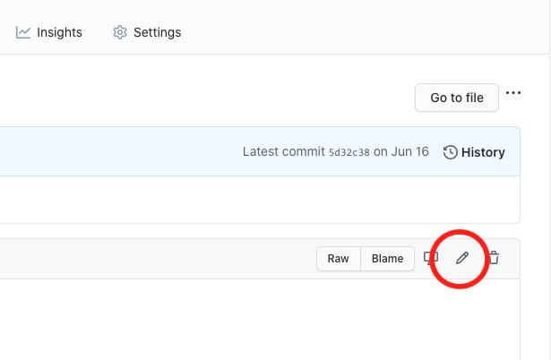

Vous obtiendrez alors un petit éditeur de code vous permettant de faire les modifications et les soumettre au dépôt de code.

Après avoir soumis votre modification, le changement ne sera pas présent instantanement en ligne. Notre site Web sera placé dans une file d’attente pour être reconstruit par Github Pages.

Vous savoir si votre modification est passée dans le générateur de site, vous pouvez consulter la [liste des modifications au dépôt de données](https://github.com/RIVE-Numeri-lab/RIVE-Numeri-lab.github.io/commits/master).

Vous verrez alors, à côté de chaque modification un petit crochet vert comme ceci :

[figure not shown]

Si le crochet n’est pas présent, c’est que votre modification est encore dans la file d’attente et que la nouvelle version du site Web n’a pas été reconstruite.

Il n’y a pas de moyen d’accélérer ce processus. En général, c’est très rapide, presque instantanné, mais il peut arriver parfois que Github Pages soit surchargé et que notre site Web prenne plusieurs minutes avant d’être reconstruit.

# Structure des contenus du site Web

En utilisant les fonctionalités de Jekyll, j’ai créé différents types et structures de contenu pour alimenter le site Web. La structure des contenus présentée ici peut évidemment être modifiée, mais elle nécessitera certains aspects de programmation.

Il existe trois types de contenus principaux sur le site Web : les pages statiques, les pages de liste et les pages de contenu.

## Les pages statiques

Les pages statiques du site Web sont les pages About us et Useful links. Leur contenu peut être modifié respectivement dans les fichiers about.md et useful_links.md à la racine du site Web (i.e. https://github.com/RIVE-Numeri-lab/RIVE-Numeri-lab.github.io). En ce sens, elles ont été pensées pour que leur contenu soit facile à modifier.

## Les pages de listes

Les pages de liste du site Web comprennent les pages News, Calendar, Workshops et Analysis Projects. Leur contenu se retrouve respectivement dans les fichiers news.html, calendar.html, workshops.html et analysis_projects.html. Le contenu de ces pages de liste contient du code HTML ainsi que du code Ruby, indiquant à Jekyll quels contenus lister dans ces pages et comment le faire. La mise à jour de ces pages devrait se faire automatiquement, à mesure que des contenus sont ajoutés au site. Elles n’ont PAS été pensées pour être facilement modifiables par un utilisateur. La page d’accueil (index.html) est elle aussi une page de liste spéciale, qui liste les contenus les plus récents provenant de plusieurs sections.

## Les page de contenus

Enfin, les pages de contenus comprennent chacune des nouvelles (trouvées dans le dossier _news), chacun des projets d’analyses (_analysis_projects) et chacun des ateliers (dans le dossier _workshops). Dans chacun des dossier, il existe une page par contenu, avec l’extension .md, permettant de facilement la modifier. Pour ajouter un contenu dans une de ces sections, il suffit de créer un nouveau fichier .md. Il sera ajouté automatiquement à la page de liste, et si il remplit les conditions, il apparaîtra aussi sur la page d’accueil.

La listes de contenus (p. ex. celle de la page formation) sont triés en se basant sur le nom du fichier .md. C’est pourquoi il est fortement recommandé de continuer à utiliser le format déjà en utilisation, qui contient la date de mise en ligne dans le nom du fichier, comme ceci : `2018-09-26-RapidDataViz.md`.

Les événements du calendrier quant à eux sont décrits dans un fichier nommé events.yml dans le dossier _data.

# Comment modifier une page Markdown (.md)

Il est important avant de s’attaquer à un fichier .md pour en modifier le contenu de garder en tête que ce n’est pas directement le fichier .md qui sera affiché sur le site Web, mais plutôt un fichier HTML que Jekyll aura créé pour nous, en se basant sur notre fichier .md.

Pour que Jekyll sache que notre fichier .md doit être converti en fichier .html, il importe que fichier comporte une entête (nommé [Front Matter](https://jekyllrb.com/docs/front-matter/) dans le jargon de Jekyll). Cette entête commence toujours par `---` seul sur une ligne et se termine aussi par un `---` seul sur sa ligne. Entre ces deux délimiteurs, vous pouvez inscrire une série d’arguments informant Jekyll de détails à propos de ce contenu (p. ex. dans quelle section mettre un atelier). Votre série d’arguments doit respecter la syntaxe (ultra simple) du langage YAML, décrite dans la prochaine section.

Pour le reste du contenu, vous pouvez utiliser du code Markdown standard pour créer des titres, des sous-titres, des liens, insérer des images, du gras, de l’italique etc. Il existe plusieurs sources décrivant le code Markdown, mais la classique est sans aucune doute celle-ci : https://www.markdownguide.org/basic-syntax/

# Comment modifier du code YAML (.yml)

Le langage yaml a été inventé pour permettre de définir les paramètres d’éxécution de code ou de sauvegarder des préférences, etc. dans un langage facile à comprendre à la fois pour les humains et les machines.

Voici un exemple de contenu YAML, provenant de la formation sur la visualisation de données :

```yaml
thumbnail: ggplot2.png
layout: default
category: Data exploration
title: "Rapid data visualization with ggplot2"
author: "Charles Martin"
date: "September 26 2018"
includes_a_video: yes
output:
  html_document:
    highlight: haddock
    keep_md: yes
    theme: readable
    toc: yes
```

Vous constatez donc qu’en général, un fichier .yml est constitué de paires d’information, séparées par un “:”. Chaque paire étant sur une nouvelle ligne. Par exemple, dans l’exemple ci-haut, j’assigne la catégorie de mon atelier à la section Data exploration.

Là où il faut être plus prudent, est lorsque l’on veut (ou doit) hiérarchiser l’information YAML, comme dans l’item `output` ci-haut. La clé ici étant que les sous-niveaux d’information doivent être indentés (plus à droite). Ainsi, l’item `highlight` est *sous* l’item `html_document` qui lui est sous l’item `output`. Faites bien attention ici de comment vous indentez vos sous-niveaux, puisque YAML est plutôt pointilleux sur cela, en principe il ne tolère que les espaces (et non les `TAB`).

## Code YAML importants à connaître pour le site Web du Numerilab.

Pour que les pages Web du site du Numerilab s’affichent correctement, il y a quelques codes YAML à bien connaître.

La première chose à mettre dans tous les codes YAML du site est `layout: default`. Cette ligne indiquera à Jekyll d’ajouter la barre de menu, les couleurs, le pied de page du site etc. Si vous oubliez cette ligne, votre contenu n’aura pas l’air de faire partie du site Web, son visuel sera différent.

Ensuite, l’item `title` est aussi important car il indiquera à Jekyll quel titre donner à nos pages. Il s’agit en fait de l’information que votre navigateur (i.e. Google Chrome) affichera dans sa barre de titre.

## Pour les pages d’ateliers et de projets d’analyse

Pour ces pages, vous avez un peu plus d’items à gérer pour que les pages s’affichent bien.

Comme mentionné plus haut, un item important est `category`, qui indique à Jekyll dans quelle catégorie mettre notre formation.

Vous pouvez aussi utiliser l’item `thumbnail` pour spécifier la vignette que Jekyll utilisera pour présenter la formation sur la page d’accueil et sur la page de liste des formations. Toutes les vignettes se trouvent dans le dossier assets/thumbnails. Vous pouvez aussi déposer de nouvelles vignettes à cet endroit.

Enfin, pour les ateliers seulement, vous pouvez ajouter l’item `includes_a_video: yes` pour afficher un petit icône qui indiquera dans la page liste que celle-ci contient une vidéo.

# Comment mettre en ligne une formation

En principe, mettre une nouvelle formation ou un nouveau projet d’analyse sur le site Web est simple. Il suffit de déposer un fichier .md dans le bon dossier et d’ajouter les quelques lignes d’en-tête YAML mentionnées ci-haut.

En principe, si l’auteur de la formation a démarré la création de sa formation à l’aide du gabarit prévu à cet effet (https://github.com/RIVE-Numeri-lab/RIVE-Numeri-lab.github.io/blob/master/Gabarit.Rmd), il devra vous arriver avec un fichier .md presque prêt à être mis en ligne.

Assurez-vous d’abord qu’il n’a pas activité l’option `selfcontained: true`. Si tel était le cas demandez-lui (ou elle) de regénérer son fichier sans cette option. Cette option aurait inséré du code binaire décrivant les images directement dans le fichier HTML, ce qui briserait la fonctionalité de fil de nouvelle (RSS Feed) du site Web.

Votre seul travail consistera à déposer les fichiers d’images associés dans le dossier assets du site Web (https://github.com/RIVE-Numeri-lab/RIVE-Numeri-lab.github.io/tree/master/assets) et de modifier la façon de référencer les images dans le fichier .md.

Lorsque vous recevrez le fichier .md, il contiendra probablement plusieurs lignes semblables à celles-ci : `![](RapidDataViz_files/figure-html/unnamed-chunk-3-1.png)`

Pour que les images s’affichent correctement sur le site Web, vous devrez les remplacer par des lignes comme celle-là : `![](/assets/RapidDataViz_files/figure-html/unnamed-chunk-3-1.png)`

Ce genre d’opération peut habituellement s’accomplir dans un éditeur de code comme RStudio en remplaçant toutes les instances de “(RapidDataViz_files” par “(/assets/RapidDataViz_files”.

Une fois toutes ces choses accomplies, la formation devrait apparaître correctement sur la page d’accueil et sur la page liste de formations.

Si quelqu’un vous arrive un fichier .html plutôt que .md, insistez fortement pour qu’il vous fournisse un fichier .md. Il est possible de créer une page de formation avec un fichier HTML, mais c’est plus complexe et cette page ne pourra pas s’afficher sur http://r-bloggers.com etc. Si jamais c’est votre seul choix, sachez que pouvez aussi insérer une entête YML à un fichier HTML, mais vous devrez probablement couper beaucoup de code HTML pour ne pas que le code de la formation interfère avec l’apparence du site Web.

# Mettre une formation disponible sur R-Bloggers.com

Si vous avez respecté toutes les conditions mentionnées ci-haut (vous avez travaillé avec un fichier .md, vous avez inséré les items correctement dans l’entête YML, vous avez remplacé le chemin des images) et que la formation s’affiche correctement sur le site Web, vous pouvez ajouter une ligne supplémentaire à l’en-tête YML pour indiquer à R-Bloggers qu’il peut afficher notre formation : `rbloggers: true`

ATTENTION : ASSUREZ-VOUS D’ÊTRE ABSOLUMENT CERTAIN QUE LA FORMATION EST PARFAITE AVANT D’INDIQUER CET ITEM. UNE FOIS SUR R-BLOGGERS, LA FORMATION Y RESTERA AINSI, MÊME SI NOUS MODIFIONS LA VERSION SUR LE SITE WEB DU NUMERILAB.